# The Full House Model for cross-era comparisons of baseball players (part II: A deeper look at results and fun digressions)

Daniel J. Eck and Shen Yan and Adrian Burgos Jr. and Christopher Kinson

### WAR and it’s usage in HOF discussions

One of the goals of WAR is to provide a framework for people like us to compare players across eras. The following passage is taken directly from the [What is WAR?](https://library.fangraphs.com/misc/war/) page on FanGraphs:

> “The goal of WAR is to provide a holistic metric of player value that allows for comparisons across team, league, year, and era and a framework for player evaluation.”

The work in this article moves WAR closer to its goal of providing fair comparisons of players who have played in vastly different eras. This matters when we evaluate a player’s career in historical context. **The Hall of Fame (HOF) players of the old past are beneficiaries of a biased performance metrics.** Comparisons based upon “vs your peers” statistics are therefore slanted in favor of old time players—specifically those who performed in the segregated NL/AL. Now this is no more. Here is a look at players who are not in the HOF but have era-adjusted bWAR values in the top 100 at the time that this was written:

| rank | name | ebWAR |
| --- | --- | --- |
| 1 | Barry Bonds | 131.03 |
| 2 | Roger Clemens | 125.77 |
| 6 | Alex Rodriguez | 102.65 |
| 12 | Albert Pujols | 89.30 |
| 15 | Adrian Beltre | 85.88 |
| 31 | Justin Verlander | 74.88 |
| 34 | Zack Greinke | 73.79 |
| 39 | Clayton Kershaw | 71.66 |
| 41 | Curt Schilling | 70.25 |
| 46 | Miguel Cabrera | 68.44 |
| 48 | Max Scherzer | 68.15 |
| 53 | Robinson Cano | 66.73 |
| 55 | Carlos Beltran | 66.25 |
| 57 | Manny Ramirez | 65.30 |
| 59 | Pete Rose | 64.00 |
| 61 | Mike Trout | 63.66 |
| 62 | Kenny Lofton | 63.57 |
| 64 | Rafael Palmeiro | 63.41 |
| 65 | Scott Rolen | 63.07 |
| 67 | Lou Whitaker | 62.80 |
| 69 | Joey Votto | 62.45 |
| 72 | CC Sabathia | 61.53 |
| 76 | Mark Buehrle | 60.67 |
| 80 | Andruw Jones | 59.61 |
| 82 | Bobby Grich | 59.28 |
| 87 | Cole Hamels | 58.30 |
| 88 | Bobby Abreu | 58.07 |
| 89 | Chase Utley | 57.65 |
| 91 | Andy Pettitte | 57.49 |
| 93 | Ichiro Suzuki | 57.27 |
| 94 | Todd Helton | 57.25 |
| 95 | Evan Longoria | 57.01 |
| 97 | Kevin Brown | 56.61 |

Here is a look at players who are not in the HOF but have era-adjusted fWAR values in the top 100 at the time that this was written:

| rank | name | efWAR |
| --- | --- | --- |
| 1 | Roger Clemens | 131.96 |
| 2 | Barry Bonds | 131.44 |
| 7 | Alex Rodriguez | 98.25 |
| 23 | Albert Pujols | 78.37 |
| 25 | Adrian Beltre | 77.80 |
| 30 | Clayton Kershaw | 75.30 |
| 31 | Justin Verlander | 74.85 |
| 40 | Zack Greinke | 70.70 |
| 44 | Curt Schilling | 68.53 |
| 45 | Miguel Cabrera | 68.19 |
| 49 | Max Scherzer | 66.11 |
| 50 | Mike Trout | 65.87 |
| 53 | Kevin Brown | 65.32 |
| 54 | Pete Rose | 65.29 |
| 57 | Carlos Beltran | 63.58 |
| 59 | Andruw Jones | 63.33 |
| 61 | Scott Rolen | 62.56 |
| 62 | CC Sabathia | 61.94 |
| 64 | Manny Ramirez | 61.61 |
| 67 | Rafael Palmeiro | 61.09 |
| 69 | Andy Pettitte | 60.53 |
| 71 | Joey Votto | 59.54 |
| 74 | Bobby Grich | 58.51 |
| 77 | Robinson Cano | 57.75 |
| 79 | Kenny Lofton | 57.37 |
| 81 | Chase Utley | 57.10 |
| 82 | Jim Edmonds | 56.95 |
| 85 | Ichiro Suzuki | 56.34 |
| 87 | Bobby Abreu | 56.01 |
| 88 | Tommy John | 55.88 |
| 93 | Lou Whitaker | 55.28 |
| 97 | Mark McGwire | 54.81 |
| 99 | Rick Reuschel | 54.66 |

Let’s focus now on the HOF candidacy for a player on this list, say Todd Helton. Jay Jaffe recently wrote an [article](https://blogs.fangraphs.com/jaws-and-the-2022-hall-of-fame-ballot-todd-helton/) on Todd Helton on Helton’s candidacy. In it, he said

> “With all facets of his game taken together, Helton’s 61.8 career WAR (bWAR) is 17th among first basemen, 5.1 WAR below the standard, and below 11 of the 21 enshrined including Bagwell, Thome, and Thomas, whose careers overlapped with his.”

For reference, the only first basemen currently ranking in front of Helton are Albert Pujols, Lou Gehrig, Jeff Bagwell, Frank Thomas, Miguel Cabrera, Jim Thome, Rafael Palmeiro, and Joey Votto. Their careers are depicted below along with the other first basemen comprising the top 100 hitters in career ebWAR:

| rank | name | PA | AB | H | HR | BB | BA | OBP | ebWAR | efWAR |
| --- | --- | --- | --- | --- | --- | --- | --- | --- | --- | --- |
| 9 | Albert Pujols | 12306 | 10778 | 3102 | 793 | 1310 | 0.288 | 0.367 | 89.30 | 78.37 |
| 22 | Lou Gehrig | 9324 | 7638 | 2065 | 483 | 1535 | 0.270 | 0.395 | 72.63 | 72.40 |
| 24 | Jeff Bagwell | 9222 | 7727 | 2122 | 497 | 1264 | 0.275 | 0.381 | 71.82 | 71.49 |
| 26 | Frank Thomas | 9686 | 7947 | 2203 | 553 | 1539 | 0.277 | 0.395 | 69.44 | 65.76 |
| 28 | Miguel Cabrera | 10920 | 9535 | 2834 | 589 | 1222 | 0.297 | 0.378 | 68.44 | 68.19 |
| 30 | Jim Thome | 9463 | 7818 | 1931 | 585 | 1513 | 0.247 | 0.371 | 67.80 | 63.74 |
| 42 | Rafael Palmeiro | 11615 | 10118 | 2632 | 551 | 1287 | 0.260 | 0.345 | 63.41 | 61.09 |
| 47 | Joey Votto | 8171 | 6664 | 1931 | 350 | 1396 | 0.290 | 0.415 | 62.45 | 59.54 |
| **65** | **Todd Helton** | **8425** | **7129** | **1901** | **326** | **1160** | **0.267** | **0.370** | **57.25** | **51.34** |
| 73 | David Ortiz | 9390 | 8065 | 2062 | 615 | 1193 | 0.256 | 0.351 | 54.10 | 48.51 |
| 77 | Keith Hernandez | 8150 | 7012 | 1912 | 179 | 1039 | 0.273 | 0.366 | 53.06 | 50.98 |
| 82 | Paul Goldschmidt | 6480 | 5536 | 1562 | 321 | 864 | 0.282 | 0.380 | 52.00 | 48.52 |
| 84 | Jimmie Foxx | 8891 | 7476 | 1740 | 490 | 1341 | 0.233 | 0.350 | 51.63 | 60.65 |
| 87 | Eddie Murray | 9020 | 7890 | 2165 | 449 | 1027 | 0.274 | 0.356 | 51.11 | 55.50 |
| 93 | John Olerud | 8715 | 7391 | 2004 | 286 | 1129 | 0.271 | 0.370 | 50.54 | 50.34 |
| 94 | Mark Teixeira | 7557 | 6506 | 1591 | 424 | 880 | 0.245 | 0.341 | 50.23 | 43.69 |
| 100 | Mark McGwire | 7130 | 5804 | 1325 | 558 | 1175 | 0.228 | 0.361 | 48.99 | 54.81 |

We hope that Jaffe and others will consider our approach when they discuss a players HOF candidacy.

### The Babe Ruth anomaly

Babe Ruth revolutionized baseball by prioritizing home run hitting as the MLB livened the baseball. As stated [here](https://www.tandfonline.com/doi/full/10.1080/09332480.2020.1726114), the single season home run record before Babe Ruth was 27 by Ned Williamson in 1884. Babe Ruth broke this record in 1919 when he hit 29 home runs. He subsequently destroyed his own record in the following 1920 season when he hit 54 home runs. The runner up in 1920 finished the season with only 15 home runs. This level of dominance has never been seen before and has never been seen sense, and it poses a problem for era-adjustment techniques.

**Babe Ruth’s dominance is in part due to his talent, but is also in part to him exercising a superior batting strategy that had not existed before. Therefore, Ruth’s “vs his peers” stats are slightly distorted, and his era-adjusted stats will also be distorted as a result.** Ruth’s projected stats into the 2021 context will reflect the combination of his talent and his competitive advantage, a competitive advantage that would not exist in today’s context. Our method will therefore overestimate Ruth’s era-adjusted home run hitting and his era-adjusted WAR since our method does not yet disentangle talent and competitivie circumstance. The problem of the Babe Ruth anomaly confounds all era-adjustment techniques. We imagine that Ruth’s era-adjusted OBP is also overestimated by our method. The Babe Ruth anomaly challenges all other era-adjustment techniques, and is especially challenging for anyone making interpretations based solely on raw or league adjusted “+” stats.

### The Tony Gwynn anomaly

Tony Gwynn has the highest era-adjusted batting average by a mile (See part I). He was a truly amazing hitter who stood very far from his peers. However, like Babe Ruth, a portion of his dominance is due to circumstance. Gywnn was one of the [early pioneers of using film to study](https://bleacherreport.com/articles/2099278-we-remember-tony-gwynn-pioneers-video-analysis-for-players-on-his-vcr) his strengths and weaknesses as well as the strengths and weaknesses of the pitchers that he faced. Nowadays film study is a basic training method available to everyone in the MLB and it is unusual and [worth mentioning](http://www.espn.com/espn/feature/story/_/id/10619342/creative-control-clayton-kershaw-abides-strict-code) when great players do not use it. Therefore, like Ruth, Gwynn’s batting average stats are slightly distorted, and his era-adjusted stats will also be distorted as a result. Gwynn’s projected stats into the 2021 context will reflect the combination of his talent and his competitive advantage, a competitive advantage that would not exist in today’s context. Our method will therefore overestimate Gwynn’s era-adjusted batting average and his era-adjusted WAR as a result.

### Mike Trout

Mike Trout is the greatest player of this current generation. The raw rankings of WAR suggests that it would be very unlikely for Trout to end his career with more WAR than the old time great players like Ruth and Cobb. **However, our era-adjustment method tells a slightly different story if Trout can stay healthy.** Below we see career trajectories for batters. Only a handful of the games greatest players have performed better through their first 11 seasons and this even sells Trout short since his first season was short and he has missed time with injuries. That being said, Trout’s injuries may catch up to him and he may not stay on his current trajectory of all-time greatness. Either way, Trout’s first 11 years have been among the best in baseball history.

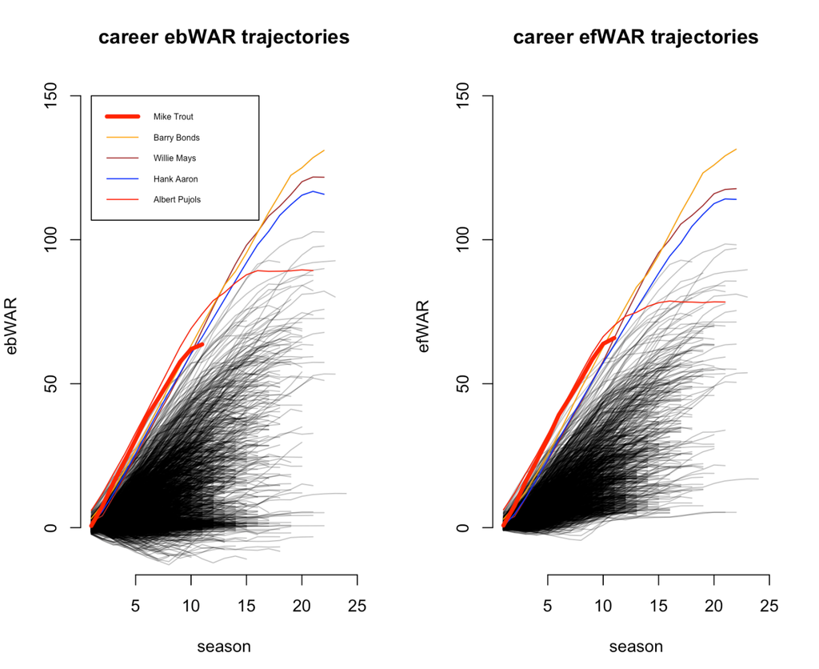

The trajectories above also indicate that Albert Pujols had the best start to a career in history as judged by era-adjusted WAR.

### Willie Stargell

When digging around the era-adjusted statistics, we found something rather exciting and unexpected. Willie Stargell ranks 4th all-time in adjusted home runs per adjusted at-bats (12.2) among players with at least 5000 adjusted plate appearances. The people in front of him are Mark McGwire, Babe Ruth, and Giancarlo Stanton! The players immediately behind him are Barry Bonds, Mike Schmidt, and Willie McCovey!

| rank | name | PA | AB | H | HR | BB | BA | OBP | ebWAR | efWAR | HR/AB |  |
| --- | --- | --- | --- | --- | --- | --- | --- | --- | --- | --- | --- | --- |
| 1 | Mark McGwire | 7130 | 5804 | 1325 | 558 | 1175 | 0.228 | 0.361 | 48.99 | 54.81 | 10.4 |  |
| 2 | Babe Ruth | 10159 | 7870 | 2104 | 715 | 2142 | 0.267 | 0.427 | 97.80 | 96.97 | 11.0 |  |
| 3 | Giancarlo Stanton | 5313 | 4590 | 1194 | 410 | 642 | 0.260 | 0.355 | 42.43 | 40.36 | 11.2 |  |
| **4** | **Willie Stargell** | **8345** | **7260** | **1857** | **593** | **925** | **0.256** | **0.343** | **42.56** | **48.79** | **12.2** |  |
| 5 | Barry Bonds | 12030 | 9560 | 2590 | 780 | 2231 | 0.271 | 0.411 | 131.03 | 131.44 | 12.3 |  |
| 6 | Mike Schmidt | 9759 | 8073 | 1823 | 655 | 1487 | 0.226 | 0.348 | 92.18 | 92.31 | 12.3 |  |
| 7 | Willie McCovey | 7903 | 6597 | 1689 | 516 | 1187 | 0.256 | 0.372 | 48.91 | 51.57 | 12.8 |  |
| 8 | Mike Trout | 5842 | 4724 | 1415 | 366 | 982 | 0.300 | 0.425 | 63.66 | 65.87 | 12.9 |  |
| 9 | Nelson Cruz | 7695 | 6830 | 1831 | 526 | 734 | 0.268 | 0.344 | 43.22 | 42.44 | 13.0 |  |
| 10T | David Ortiz | 9390 | 8065 | 2062 | 615 | 1193 | 0.256 | 0.351 | 54.10 | 48.51 | 13.1 |  |
| 10T | Harmon Killebrew | 8572 | 7004 | 1463 | 534 | 1440 | 0.209 | 0.345 | 44.26 | 49.07 | 13.1 |  |

We can see that Stargell was one of the most prolific power hitters of all-time when one takes into account the extended pitching dominance in the 60s, the post-integration surge of players into the 1970s, and his long time home park Forbes Field which was notoriously hard on left handed batters. It is interesting to see what speculation was written about Stargell in the second to last paragraph of his [SABR bio](https://sabr.org/bioproj/person/willie-stargell/):

> “At the time of his retirement, Stargell’s 475 home runs tied him with Stan Musial for 15th on the all-time list. As legendary a power hitter as he was, one is still tempted to ask, “What if?” What if he hadn’t played eight-and-a-half years in the home run graveyard of Forbes Field? What if his knees had held up? What if he had been more serious about staying in shape early in his career? Four-hundred-seventy-five home runs, of course, is an extraordinary achievement. But one could imagine how a consistently healthy, consistently fit Stargell shooting at a more inviting right field porch could have boosted that total to well over 500; maybe even, as he suggested himself, close to 600."

Our method has Stargell at 593 era-adjusted home runs, which is very close to 600. So Willie Stargell got it right (in today’s context), he would hit close to 600 home runs if he were consistently fit and moved to a more forgiving ball park. Willie Stargell is a causality of the WAR movement and era-adjusted WAR does not revitalize his image. But we should think of Stargell as a slugger and not just any slugger at that, he was one of the most efficient and prolific home run hitters of all time. [This](https://www.youtube.com/watch?v=XBeels-WDko) is the mental image we should have in mind when we think of Willie Stargell.

Here is a look at Stargell’s era-adjusted statistics. We can marvel at his 1971-1973 prime slugging years

| name | age | year | PA | AB | H | HR | BB | BA | OBP | ebWAR | efWAR |
| --- | --- | --- | --- | --- | --- | --- | --- | --- | --- | --- | --- |
| Willie Stargell | 23 | 1963 | 319 | 286 | 57 | 13 | 25 | 0.199 | 0.266 | -1.05 | -0.25 |
| Willie Stargell | 24 | 1964 | 402 | 365 | 89 | 25 | 36 | 0.244 | 0.314 | 0.72 | 0.86 |
| Willie Stargell | 25 | 1965 | 562 | 502 | 127 | 40 | 52 | 0.253 | 0.330 | 2.48 | 2.37 |
| Willie Stargell | 26 | 1966 | 532 | 458 | 126 | 43 | 58 | 0.275 | 0.361 | 3.16 | 3.33 |
| Willie Stargell | 27 | 1967 | 516 | 440 | 106 | 32 | 64 | 0.241 | 0.340 | 1.77 | 2.10 |
| Willie Stargell | 28 | 1968 | 508 | 435 | 94 | 34 | 58 | 0.216 | 0.312 | 1.14 | 1.76 |
| Willie Stargell | 29 | 1969 | 573 | 501 | 133 | 37 | 60 | 0.265 | 0.348 | 3.29 | 3.49 |
| Willie Stargell | 30 | 1970 | 526 | 469 | 113 | 40 | 55 | 0.241 | 0.323 | 2.55 | 2.86 |
| Willie Stargell | 31 | 1971 | 594 | 508 | 142 | 53 | 71 | 0.280 | 0.372 | 5.97 | 6.19 |
| Willie Stargell | 32 | 1972 | 585 | 511 | 146 | 50 | 68 | 0.286 | 0.367 | 4.63 | 5.31 |
| Willie Stargell | 33 | 1973 | 574 | 497 | 143 | 51 | 70 | 0.288 | 0.376 | 5.47 | 6.03 |
| Willie Stargell | 34 | 1974 | 574 | 487 | 137 | 41 | 70 | 0.281 | 0.376 | 4.40 | 4.92 |
| Willie Stargell | 35 | 1975 | 492 | 432 | 118 | 30 | 55 | 0.273 | 0.356 | 2.69 | 3.14 |
| Willie Stargell | 36 | 1976 | 445 | 387 | 96 | 28 | 49 | 0.248 | 0.337 | 0.45 | 1.13 |
| Willie Stargell | 37 | 1977 | 156 | 129 | 30 | 11 | 32 | 0.233 | 0.392 | 0.80 | 1.15 |
| Willie Stargell | 38 | 1978 | 395 | 340 | 85 | 28 | 41 | 0.250 | 0.340 | 1.77 | 2.01 |
| Willie Stargell | 39 | 1979 | 412 | 360 | 84 | 27 | 36 | 0.233 | 0.304 | 1.42 | 1.56 |
| Willie Stargell | 40 | 1980 | 140 | 121 | 24 | 8 | 18 | 0.198 | 0.310 | 0.90 | 0.81 |
| Willie Stargell | 41 | 1981 | 20 | 17 | 4 | 1 | 6 | 0.235 | 0.417 | 0.01 | 0.01 |
| Willie Stargell | 42 | 1982 | 20 | 15 | 3 | 1 | 1 | 0.200 | 0.222 | -0.01 | 0.01 |

### ZiPS Projections

Let’s visit ZiPS Projections before we conclude this work. Dan Szymborski closes [a recent article](https://blogs.fangraphs.com/elegy-for-2021-recapping-the-nl-east-team-by-team/) with a discussion on outlandish Juan Soto projections to which he says

> “I’ll admit it: I just wanted to see Soto break ZiPS. And I think he might have. Last spring, I spent some time talking with Jayson Stark about whether Soto was the next Ted Williams. The amazing thing is that neither of us thought the idea was absurd. MLB should simply redefine the strike zone as”whatever Juan Soto won’t swing at." He might not always be the best overall player, but he’s the most gifted offensive player of this generation."

Here are the outlandish percentile Soto projections that Szymborski references:

[figure not shown]

Szymborski refers to Soto as breaking ZiPS. In other words, the projection system is unreliable for Soto. **We do not think that players break projection systems. Rather, projection systems are themselves broken if they produce nonsensical forecasts for players.** We do not know the inner mechanics of the ZiPS Projection System. **If it borrows information from great players of the past to inform predictions about great players of the present, then its outputs may reflect era biases which have been discussed throughout this work.** In a very unpopular public comment, one of the authors of this work was willing to bet the under of the ZiPS 90th percentile of the Soto projections under the premise that it may have embedded era biases. This author received a lot of public flack, perhaps deservedly so, but ultimately got zero takers.

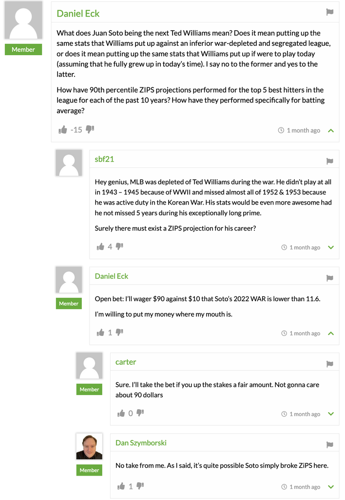

We appreciate Dan Szymborski for even taking the time to acknowledge the circus that surrounded our point. We also enjoyed Dan revealing that an unadulterated Ted Williams is indeed [Juan Soto’s closest comp](https://blogs.fangraphs.com/2022-zips-projections-washington-nationals/).

### Other adjustment strategies: Era-bridging

We revisit some of the commentary about [BRL’s](https://www.vanderbilt.edu/psychological_sciences/graduate/programs/quantitative-methods/quantitative-content/berry_reese_larkey_1999.pdf) era-bridging method made in [my previous article](https://community.fangraphs.com/challenging-war-and-other-statistics-as-era-adjustment-tools/). Recall that BRL developed an era-bridging technique involving hierarchical Bayesian models which they claim serves the role of a statistical time machine that allows for all players to be compared directly. They state:

> “The goal is not to judge players relative to their contemporaries, but rather to compare all players directly. Hence the model that we use is a statistical time machine. We use additive models to estimate the innate ability of players, the effects of aging on performance, and the relative difficulty of each year within a sport. We measure each of these effects separated from the others. We use hierarchical models to model the distribution of players and specify separate distributions for each decade, thus allowing the”talent pool" within each sport to change. We study the changing talent pool in each sport and address Gould’s conjecture about the way in which populations change."

BRL’s addressing of Gould’s conjecture is summarized with the following passage:

> “The globalization has been less pronounced in MLB, where players are drawn mainly from the United States and other countries in the Americas. Baseball has remained fairly stable within the United States, where it has been an important part of the culture for more than a century.”

This rationale is not wrong relative to the other sports under study by BRL. **However, BRL’s rationale ignores segregation in its modeling construction (although segregation is mentioned by BRL), increases in the MLB eligible population relative to available roster spots, and increases in the average overall talent of that population.** It also downplays the demographic change in MLB produced by racial integration as noted by [Armour](https://sabr.org/bioproj/topic/baseball-demographics-1947-2016/). In addition this model treats NL/AL players from all generations as interchangeable in the sense that they are all NL/AL caliber players regardless of which era they played. Plainly put, the expanded racial diversity of those performing in NL/AL literally meant white major leaguers who might have played a decade earlier were replaced by talented African American and Latino players that were previously excluded from MLB.

All of the above concerns are partially addressed by the modeling formulation which is parametric in nature and requires the complex changing dynamics to be captured by the parametric assumptions that they impose. In a [previous article](https://community.fangraphs.com/challenging-war-and-other-statistics-as-era-adjustment-tools/) it was stated that:

> “We found that BRL did not fully account for Gould’s conjecture in the context of baseball. We also found it odd that the BRL model predicts that a .300 hitter in 1996 will have a lower than .300 average for several seasons from 1900–20. This conflicts with the well-established notion that the talent of baseball players has improved over time. Perhaps the decadal hierarchical modeling approach did not capture the changing dynamics of the underlying talent pool or perhaps the distributional assumptions made were inappropriate.”

While it is true that the BRL approach predicts that a .300 hitter in 1996 will have a lower than .300 average for several seasons from 1900–20, it is also true that the effects of deadball era shares blame with the notion that the talent of baseball players has improved over time. That being said, the Full House Model predicts that a .300 hitter in 1996 will have a greater than .300 average for all seasons in the 1900-20 period.

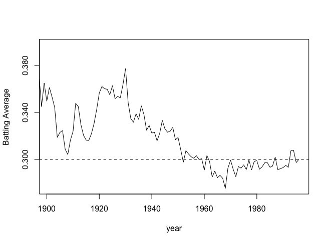

But it is perhaps each model’s handling of World War II (WWII) that best illustrates the inferiority of BRL’s era-bridging approach. According to Dan Olmsted at the [The National WWII Museum](https://www.nationalww2museum.org/war/wwii-polls/roper-polls-major-league-baseball-world-war-ii) over 500 major leaguers served in the military during World War II, including future Hall of Famers Ted Williams, Stan Musial, Hank Greenberg, Bob Feller, and Joe DiMaggio, not to mention the thousands of minor leaguers. There were at least 3 MLB players and 177 minor leaguers who were [killed in these wars](http://www.baseballsgreatestsacrifice.com). This tally does not include [far from complete tally of the wounded](http://www.baseballsgreatestsacrifice.com/wounded_in_combat.html) or the [sheer number of soldiers](https://www.alternatewars.com/BBOW/Stats/US_Mil_Manpower_1789-1997.htm) that may have made a career out of the military or decided to pursue other professions than baseball after returning from war.

It is fair to say that WWII had gutted both the talent pool feeding into the MLB and talent level of the MLB. Our first thought would be to think that the gutted MLB would be readily apparent in a study of the changing distributions of baseball statistics. But this is not really the case. **First of all, WAR is fixed to the number of possible wins and therefore exhibits no attachment to changing talent dynamics, the computation of WAR is the same regardless of the level of talent in the MLB.** But certainly batting averages would be affected? No, not really. **WWII drained both the batters and the pitchers and the balance between the two was preserved.** Thus the dynamics articulated by Steve Jay Gould take hold. Here is a look at four statistical moments of the batting average distribution over time where the points in red correspond to seasons surrounding the peak of WWII (1941-1946):

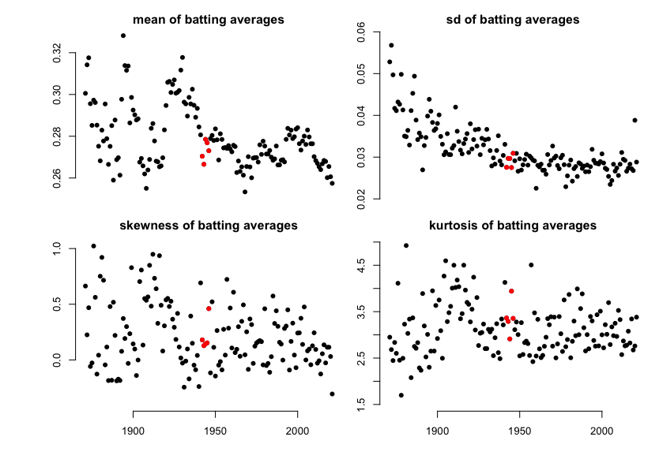

We can see that the distribution of batting averages during WWII seasons are not really any different than those of other seasons, and they do not differ dramatically from the batting average distributions of seasons immediately preceding and following WWII. **Therefore, BRL’s era-bridging hierarchical Bayesian method will not diagnose or correctly handle the WWII seasons. Their decadal and seasonal random effects will not reveal a difference in talent over those seasons. Therefore, era-bridging will overestimate the productivity of players during that time and will give false under projections for other player seasons which are mapped into the WWII baseball years.**

### Joe Posnanski’s recent rankings list

Recently Joe Posnanski produced a list of the 100 greatest players of all time at the [Athletic](https://theathletic.com/1457115/2019/12/17/the-baseball-100-a-project-celebrating-the-greatest-players-in-history/). Posnanski had this to say about this ranking list:

Some of it is science, but admittedly some of it also art. I [Joe Posnanski] will give you a handful of guiding principles:

1. I think today’s players tend to be underrated compared to those who came before them.
2. I lean toward players who were great at their peak, even if that peak only lasted a short time, and lean away from those who were consistently but not toweringly good for a long time.
3. I lean toward players who did multiple things well over specialists (no matter how great) who basically did just one thing well.
4. I take a lot of care to make educated guesses about players whose careers were shortened by things beyond their control — World War II, for example, or baseball’s tragic and infuriating color line. I don’t make the same adjustment for injuries. As Bill James has written, there’s a big difference. The years when Joe DiMaggio or Ted Williams or Bob Feller were at war, the years when Josh Gibson and Oscar Charleston played in the Negro Leagues, they were still the best players on earth. They just couldn’t play in the big leagues because of larger issues. When players get hurt — take Don Mattingly, for example, and his back problems — they stop being the best players in the world. I wish Donnie Baseball didn’t get hurt, we all do, but he did, and he was never quite the same player after that. That’s not the same as saying that Bob Feller lost four years when he was still the best pitcher on earth.

We provide Posnanski’s top 25 NL/AL players of all-time along with our top 25 NL/AL players ranked by era-adjusted bWAR and era-adusted fWAR. Players who began their careers before baseball was integrated are indicated by bold text:

|  | Posnanski’s list | ebWAR | efWAR |
| --- | --- | --- | --- |
| 1 | Willie Mays | Barry Bonds | Roger Clemens |
| 2 | **Babe Ruth** | Roger Clemens | Barry Bonds |
| 3 | Barry Bonds | Willie Mays | Willie Mays |
| 4 | Hank Aaron | Henry Aaron | Henry Aaron |
| 5 | **Ted Williams** | **Babe Ruth** | Greg Maddux |
| 6 | **Walter Johnson** | Alex Rodriguez | **Babe Ruth** |
| 7 | **Ty Cobb** | Greg Maddux | Alex Rodriguez |
| 8 | **Stan Musial** | Randy Johnson | Randy Johnson |
| 9 | Mickey Mantle | Rickey Henderson | Mike Schmidt |
| 10 | **Honus Wagner** | Mike Schmidt | Nolan Ryan |
| 11 | Roger Clemens | **Stan Musial** | Rickey Henderson |
| 12 | **Lou Gehrig** | Albert Pujols | **Ted Williams** |
| 13 | Alex Rodriguez | Frank Robinson | **Stan Musial** |
| 14 | **Rogers Hornsby** | Tom Seaver | Frank Robinson |
| 15 | **Tris Speaker** | Adrian Beltre | Steve Carlton |
| 16 | Mike Schmidt | **Ted Williams** | Bert Blyleven |
| 17 | Frank Robinson | **Walter Johnson** | Cal Ripken Jr. |
| 18 | Joe Morgan | Cal Ripken Jr. | Gaylord Perry |
| 19 | **Lefty Grove** | **Cy Young** | **Cy Young** |
| 20 | Albert Pujols | **Ty Cobb** | **Ty Cobb** |
| 21 | Rickey Henderson | **Lefty Grove** | Mickey Mantle |
| 22 | **Pete Alexander** | Chipper Jones | **Walter Johnson** |
| 23 | Mike Trout | Bert Blyleven | Albert Pujols |
| 24 | Randy Johnson | Eddie Mathews | **Lefty Grove** |
| 25 | **Eddie Collins** | Mike Mussina | Adrian Beltre |

We appreciate that Posnanski used an artistic as well as a scientific process to come up with the above rankings, and we appreciate the thinking that today’s players are underrated compared to those who came before them. But we feel that whatever reasoning led to putting Willie Mays ahead of Babe Ruth should have also placed Rickey Henderson ahead of Ty Cobb, Albert Pujols ahead of Lou Gehrig, Cal Ripken Jr. ahead of Honus Wagner, and both Randy Johnson and Greg Maddux ahead of Walter Johnson.

We also note that Posnanski’s list contains 6 players who began their career before integration in his top 10 list, and 12 players who began their career before integration in his top 25 list. By our calculations, the chance of observing 12 or more pre-integration players in a top 25 list is about 1 in 1250, and the chance of observing 6 or more pre-integration players in a top 10 list is about 1 in 230. Thus, Posnanski has included too many old time players in his rankings of the greatest all-time players. Meanwhile, the chance of observing 7 or more pre-integration players in a top 25 list is about 1 in 6, and the chance of observing 1 or more pre-integration players in a top 10 list is about 1 in 1.15. Our method is therefore right in alignment with what we would expect.

Posnanski has the advantage of not being married to a formula and can naturally account for things like steroids, amphetamine usage, and all-time talents like Trout not having enough seasons to belong to a career list based solely on career totals. We would enjoy seeing what Posnanski’s list would look like if he started with our era-adjusted rankings. That being said, we probably need to era-adjust Negro League statistics before Posnanski weighs in. We will have those results [real soon now](http://catb.org/jargon/oldversions/jarg271.txt).

### Comparing a Player Outside His Era: Bill James and Tom Tango

Bill James published a [fascinating conversation](https://www.billjamesonline.com/comparing_a_player_outside_his_era/) between Tom Tango and himself on the subject of cross-era comparisons. There are many nuggets from this conversation which deserve attention, but in the interest of brevity, we will only focus on a few segments.

Simplifying a little, Tom Tango’s initial position is that we should only compare players to their contemporaries in the strictest of senses. He says:

> “You have about 12-15 nonpitcher in the HOF for any 10-11 year time period. If Andruw Jones [a player whose HOF candidcay that Bill and Tom are discussing] is one of the top 12 nonpitcher among his peers, great. If he’s one of the 40 nonpitchers born 1962-1992, great. (Though these numbers can be argued based on expansion.)… This way, we don’t have to make”timeline" adjustments. That’s me though."

Bill’s response is very lengthy (although not as lengthy as what you have read here). One of his main points of response is:

> "Yes, of course it is difficult to make cross-generational comparisons in baseball, but you ignore the fact that we have a constant frame of reference which applies across time and which stabilizes the data across time: Wins. IF you can state a player’s contribution to his team in terms of wins and losses, then you have a valid basis for comparing a player from 1968 to a player in 2008—leaving only the large problem of the relative quality of play over time, and the relatively small issues of the length of the schedule and what to do with post-season play.

> And, in fact, we HAVE 85% solved the problem(s) of stating a player’s contribution to his team in terms of wins and losses. Yes, we still have the WAR/Wins and Losses Issue and the many problems inherent in WAR, but what we DO know about this issue now is much larger than what we do not know—unlike 1975, when we had not even reached the understanding that we needed to state these contributions in constant terms, and that wins was the constant unit which guides the debate.

Tom responds with:

> "Inherent in the wins-as-the-great-equalizer debate is that it treats winning percentage of .500 as a constant. This forces a specific mindset: (a) do you adjust this across time, so that a .500 win% in 1917 is not the same as in 2017? (b) do you accept it is the same, solely for the purposes of peer-comparisons?

> If you accept (b), we’re holding the players accountable to their era only. And so any comparison of Ty Cobb to Rickey Henderson is limited to their comparisons to their direct peers, and then players of the early 1900s, as a group, are being treated as equals to the players of the 1980s and of today (.500 = .500). So, we’re actually comparing Cobb and Rickey through this “common baseline”.

> If you accept (a), you need to accept that players have gotten better across time, just like in every other sport, and so, the average player in Cobb’s time would likely be a bench player today, at best. I say this not only because players must have gotten physically stronger and faster, but also because 3/8ths of the best players today would have been precluded from playing during the segregation era. If we use players of the 1900s as any kind of benchmark, by this assumption, we’d be voting in ten players every year.

> In my view, before we jump through the hoops that a careful timeline comparison would require, (including establishing which of the two assumptions to follow, of which no one will agree with anyway) let’s at least do the easy part and compare players to their direct peers."

**In our view, the Full House Model IS the careful timeline comparison sought by Tom Tango, and it renders his mindset distinctions between (a) and (b) moot.** The Full House Model takes statistics like WAR and corrects for its existing era-biases through a balancing of how one performs “vs their peers” and how many people are eligible to play in the MLB.

Tom is right when he suggests that we would be voting in more players every year if we actually approach HOF candidates by their era-adjusted talent. It seems that he is stating this as a drawback which, if true, would be very disappointing considering that older players’ statistics are inflated as a result of racial segregation.